# Aplicación del aprendizaje automático al laboratorio de diagnóstico clínico: Detección temprana de series analíticas fuera de control en análisis inmunoquímicos de muestras de sangre mediante algoritmos de Machine Learning

Sergio García Muñoz

2023-05-29

# Instalación y carga de paquetes requeridos:

```r
require(readr)
require(readxl)
require(purrr)
require(dplyr)
require(filesstrings)
require(stringr)
require(tidyr)
require(lubridate)
require(ggplot2)
require(caret)
require(wavelets)
require(tictoc)
require(reticulate)
require(abind)
require(tensorflow)
require(tfdatasets)
require(keras)
```

## Definición de rutas y directorios

```r
# Definir el directorio donde se encuentran los archivos de datos:
workingdir <- getwd()
datadir <- file.path(workingdir, "Datos/daily_s")
eventdir <- file.path(workingdir, "Datos/daily_s/Event")
eventdir_old <- file.path(workingdir, "Datos/daily_s/Event/old")
lotdir <- file.path(workingdir, "Datos/daily_s/Lot")
lotdir_old <- file.path(workingdir, "Datos/daily_s/Lot/old")
qcdir <- file.path(workingdir, "Datos/daily_s/qc")
qcdir_old <- file.path(workingdir, "Datos/daily_s/qc/old")
resultsdir <- file.path(workingdir, "Resultados")
figuresdir <- file.path(workingdir, "Resultados/Figuras")

# Definir el intervalo de tiempo en segundos entre las lecturas
interval <- 60
```

# Definición de funciones:

## Función `read_lot`.

Lee los archivos csv de lotes y crear un data frame.

```r
read_lot <- function(CLC=NULL) {
  # Crea una lista de archivos existentes en datadir            correspondientes a los lotes diarios:
  files_list <- list.files(lotdir, pattern = "Lote_",
                           full.names = T)

  # Especifica los tipos de datos que contiene cada columna:
  col_types <- cols(
  PACIENTE_EDAD = col_integer(),
  RESULTADO = col_double()
  )

  # Especifica que el separador decimal es ",":
  locale_decimal_comma <- locale(decimal_mark = ",")

  # Crea una lista de dataframes leyendo cada archivo:
  df_list <- map(files_list,
                 ~read_delim(.x,
                             delim = "|",
                             col_select = -8,
                             col_types = col_types,
                             trim_ws = T,
                             locale
                             =locale_decimal_comma))

  # Crea el dataframe final:
  df <- bind_rows(df_list)

  # Convierte múltiples formatos de fecha y hora de la columna         FECHA_RECEPCIÓN en formato POSIXct, cambia formato fecha y         nombre de columna:

  df[[1]] <- dmy_hms(df[[1]])
  colnames(df)[1] <- "TIEMPO_MUESTRA"

  # Elimina una parte del string del nombre del analizador no utilizable:
  df[[2]] <- substring(df[[2]],10, 21)

  # Filtra los resultados según el CLC introducido si es distinto de nulo:
  if (!is.null(CLC)){
    df %<>% filter(., CODIGO_PRUEBA == CLC)
  }

  # Mueve el archivo leído a la carpeta old:
  # file.move(files_list, lotdir_old, overwrite = TRUE)

  return(df)
}
```

## Función `read_lotX`.

Lee los archivos csv de lotes con distintos formatos de fecha y crear un data frame.

```r
read_lotX <- function(CLC=NULL) {
  # Crea una lista de archivos existentes en datadir            correspondientes a los lotes diarios:
  files_list <- list.files(lotdir, pattern = "LoteX_",
                           full.names = T)

  # Especifica los tipos de datos que contiene cada columna:
  col_types <- cols(
  PACIENTE_EDAD = col_integer(),
  RESULTADO = col_double()
  )

  # Especifica que el separador decimal es ",":
  locale_decimal_comma <- locale(decimal_mark = ",")

  # Crea una lista de dataframes leyendo cada archivo:
  df_list <- map(files_list,
                 ~read_delim(.x,
                             delim = "|",
                             col_select = -8,
                             col_types = col_types,
                             trim_ws = T,
                             locale
                             =locale_decimal_comma))

  # Crea el dataframe final:
  df <- bind_rows(df_list)

  # Convierte múltiples formatos de fecha y hora de la columna         FECHA_RECEPCIÓN en formato POSIXct, cambia formato fecha y nombre    de columna:

  df[[1]] <- mdy_hm(df[[1]], tz=Sys.timezone())
  colnames(df)[1] <- "TIEMPO_MUESTRA"

  # Elimina una parte del string del nombre del analizador   no utilizable:
  df[[2]] <- substring(df[[2]],10, 21)

  # Filtra los resultados según el CLC introducido si es distinto de nulo:
  if (!is.null(CLC)){
    df %<>% filter(., CODIGO_PRUEBA == CLC)
  }

  # Mueve el archivo leído a la carpeta old:
  # file.move(files_list, lotdir_old, overwrite = TRUE)

  return(df)
}
```

## Función `read_event`.

Lectura de los archivos csv de eventos y crear un data frame.

```r
read_event <- function() {
  # Crea una lista de archivos existentes en datadir            correspondientes a los eventos de QC diarios:
  files_list <- list.files(eventdir, pattern = "Evento_",
                           full.names = T)

  # Especifica los tipos de datos que contiene cada columna:
  col_types <- cols(
  FECHA = col_character(),
  LOTE = col_integer())

  # Crea una lista de dataframes leyendo cada archivo:
  df_list <- map(files_list,
                 ~read_delim(.x,
                             delim = "|",
                             col_types = col_types,
                             col_select = -c("LOTE"),
                             trim_ws = T))

  # Crea el dataframe final:
  df <- bind_rows(df_list)

  # Convierte la fecha leída como string en formato POSIXct y cambia   nombre a columna:
  df[[1]] <- as.POSIXct(gsub(",", ".", df[[1]]),
               format = "%d/%m/%y %H:%M:%S",
               tz=Sys.timezone())
  colnames(df)[[1]] <- "TIEMPO_EVENTO"

  # Elimina substring no deseado en el nombre del            analizador:
  df[[2]] <- substring(df[[2]],10, 21)

  # Mueve el archivo leído a la carpeta old:
  #file.move(files_list, eventdir_old, overwrite = TRUE)

  return(df)
}
```

## Función `read_qc`.

Lee los archivos xls de valores de QC para cada técnica y cada máquina, añade una columna con la id del equipo, otra con el código CLC de la prueba y crea un data frame final. La función contiene una condición if diseñada por el diferente formato de exportación de los archivos del control en uso y el histórico de controles inactivos.

```r
read_qc <- function() {
  # Crear una lista de archivos existentes en datadir que contienen los valores de QC, tanto en uso como inactivos:
  files_list <- list.files(qcdir, pattern = "CLC",
                           full.names = T)

  # Lista vacía para contener los dataframes originados en el loop:
  list_df <- list()

  # Loop for para crear una lista de dataframes leyendo cada           archivo de qc:
  for(i in 1:length(files_list)){
    data <- read_xls(files_list[i], skip = 4)

    # Buscar y extraer el id del equipo en la primera fila:
    dev_ids <- c("DXI800 num 1", "DXI800 num 2",
             "DXI800 num 3")
    first_rows <- read_xls(files_list[i],
                        col_names = F, n_max = 3)
    match_dev <- which(grepl(paste(dev_ids,
                                   collapse = "|"),
                                   first_rows))
    start_pos <- regexpr("(?<=DxI)\\S+",
                         first_rows[match_dev],
                         perl = TRUE)
    dev <- substring(first_rows[match_dev], start_pos)

    # Extraer el código CLC del nombre del archivo
    start_pos <- regexpr("(?<=CLC)\\S+",
                         files_list[i],
                         perl = TRUE)
    end_pos <- regexpr("\\)", files_list[i], start_pos)
    clc <- substring(files_list[i], start_pos, end_pos - 1)

    # Añadir como columnas "ANALIZADOR" y "CODIGO_PRUEBA" las cadenas     extraídas:
    data %<>% mutate("ANALIZADOR"= substr(dev, 13, 24),
                     "CODIGO_PRUEBA"= paste("CLC",clc, sep = "")) %>%
              relocate("ANALIZADOR", "CODIGO_PRUEBA", .after = 5)

    # En caso de que el archivo de datos sea del histórico, la    identificación del control no se encuentra como columna, sino     en la cabecera, ya que los archivos han sido generados para cada  nivel de control individualmente.
    # Identificación de este tipo de archivo, extracción de la identificación y creación de la columna "Control":

    if(!("Control" %in% colnames(data))) {
      # Extraer el nombre del control de la fila 3, columna D:
      cont <- read_xls(files_list[i],
                        col_names = F, range = "D2:D2")
      data %<>% mutate("Control"= as.character(cont)) %>%
              relocate("Control", .after = 4)
      }

    # Agrega el dataframe actual a la lista:
    list_df[[i]] <- data
  }

  # Unir todos los dataframes en uno solo:
  df <- bind_rows(list_df)

  # Cambia el nombre a la columna Lote de reactivos:
  colnames(df)[10] <- "LOTE_REACTIVO"

  # Fusiona las columnas de los valores de concentraciones         encontrados en distintas unidades en una sola columna:
   df <- unite(df, "Resultado", c(3, 13:21),  sep = "", na.rm = T)

  # Reordena el dataframe:
   df %<>% relocate("Sup/Inf Media", .after = 4)

  # Cambia el nombre a la columna Lote de reactivos:
  colnames(df)[3] <- "QC_RESULT"

   # Mueve el archivo leído a la carpeta old:
  # file.move(files_list, qc_old, overwrite = TRUE)

  return(df)
}
```

## Función `figure_ext`.

Extracción de datos numéricos de la columna media y sd.

```r
figure_ext <- function(df, col_number) {
  # Extrae números presentes en la columna especificada:
  mean_val <- c()
  sd_val <- c()
  for (i in 1:nrow(df[col_number])){
    numbers <- str_extract_all(df[i, col_number],
                             "\\d+(\\.\\d+)?")

    # Convertir a decimal y hallar media y sd:
    numbers <- as.double(unlist(numbers))
    mean_val <- rbind(mean_val,
                        (numbers[1] + numbers[2])/2)
    sd_val <- rbind(sd_val,
                      (numbers[2] - numbers[1])/2)
  }

  # Crear nuevas columnas media y sd:

  df %<>% mutate("Media" = mean_val, "SD" = sd_val) %>%
          relocate("Media", "SD", .after =3)

  # Borrar columna original
  df[[col_number]] <- NULL

  # Devolver el dataframe modificado
  return(df)
}
```

## Función `merge_date`.

Fusiona columnas Fecha y Hora en una nueva columna Fecha_hora y borra las columnas individuales.

```r
  merge_date <- function(df){
    df %<>%
      mutate("TIEMPO_QC" =
               as.POSIXct(paste(Fecha, Hora),
                          format = "%d/%m/%y %H:%M:%S",
                          tz=Sys.timezone()),
             .before = 1)
    # Borrar columnas originales
    df[["Fecha"]] <- NULL
    df[["Hora"]] <- NULL

  return(df)
}
```

## Función `merge_feat_qc`.

```r
merge_feat_qc <- function(df1, df2){
  # Crear timestamps con solo la fecha:
  df1$rounded_date <- floor_date(as.Date(df1[[1]])+1,
                                 unit = "day")
  df2$rounded_date <- floor_date(as.Date(df2[[1]]),
                                 unit = "day")

  # Crear un nuevo dataframe con merge (equivale a left outer join):
  merged_df <- merge(df1, df2,
                     by = c("rounded_date", "ANALIZADOR",
                            "CODIGO_PRUEBA", "LOTE_REACTIVO"))

  # Borrar los timestamps con solo fecha:
  merged_df$rounded_date <- NULL
  merged_df$rounded_date <- NULL

  return(merged_df)

}
```

## Función `merge_feat_qc_event`.

Une los dataframes feat_qc y events a día D en uno solo mediante Left outer join. Añade la posibilidad de filtrar por códigos de prueba para seguir trabajando con un subconjunto de las mismas.

```r
merge_featqc_event <- function(df1, df2, CLC=NULL){

  # Crear rounded_date sin hora, solo fecha:
  df1$rounded_date <- floor_date(as.Date(df1[[10]]),
                                 unit = "day")
  df2$rounded_date <- floor_date(as.Date(df2[[1]]),
                                 unit = "day")

  # Crear un nuevo dataframe con merge (equivale a left outer join):
  merged_df <- merge(df1, df2,
                     by = c("rounded_date", "ANALIZADOR",
                            "CODIGO_PRUEBA"), all.x = T)  %>%
               unique()

  # Borrar rounded_date:
  merged_df$rounded_date <- NULL

  # Filtrado en caso de que se requiera por CODIGO_PRUEBA:
  if (!is.null(CLC)){
    merged_df %<>% filter(., CODIGO_PRUEBA == CLC)
  }

  return(merged_df)

}
```

## Función `wt`.

Función para la aplicación de la transformación wavelet de tipo Maximal Overlap Discrete Wavelet Transformation (MODWT) que devuelve los coeficientes de wavelet y los coeficientes de escalado.

```r
wt <- function(x, wavefun){
  mod <- modwt(x, wavefun, boundary = "periodic")
return(mod)
}
```

## Función `wavelet_tr`.

Aplica la transformación wavelet a un dataframe df agrupado según variables agrupadas y devuelve un dataframe con los coeficientes y escalas para cada observación.

```r
wavelet_tr <- function(df) {
  # Aplicar la función wt a cada grupo por separado
  df_wavelet <- df %>%
    group_by(ANALIZADOR, CODIGO_PRUEBA) %>%
    mutate(
      across(RESULTADO, ~ cbind(.x, as.data.frame(wt(.x, "la20")@W),
                                as.data.frame(wt(.x, "la20")@V)))
    ) %>%
    ungroup() %>%
    unnest(cols = RESULTADO)

  # Reordenar columnas
  df_wavelet <- df_wavelet %>%
    relocate(starts_with("RESULTADO"), .after = 1) %>%
    relocate(starts_with("W"), .after = 2) %>%
    relocate(starts_with("V"), .before = PACIENTE_SEXO)

  # Sustituir valores NA en los coeficientes wavelet por un valor arbitrario -99999 para su posterior filtrado
  wavelet_cols <- grep("^[WV]", colnames(df_wavelet), value = TRUE)

  return(df_wavelet)
}
```

## Función `normalize_train`.

Para la normalización de las variables continuas del dataset de entrenamiento y sustitución de valores NA en los coeficientes wavelet por un valor numérico arbitrario fácilmente enmascarable. Devuelve también una lista de vectores de medias y de desviaciones estándar que luego se usan como argumentos en para las funciones de normalización de los datasets de validación y test. De esta forma, el escalado y normalización se realiza con la misma media y desviación del set de entrenamiento para los otros dos datasets.

```r
normalize_train <- function(data) {

  # Identificar las columnas que empiezan por W y la columna 'RESULTADO'
  wavelet_cols <- grep("^[WV]", colnames(data), value = TRUE)
  result_col <- "RESULTADO"

  # Calcular medias y desviaciones estándar por grupos de pruebas y   analizador:
  means <- data %>%
    group_by(ANALIZADOR, CODIGO_PRUEBA) %>%
    summarise(across(c(result_col, wavelet_cols),
                     ~mean(., na.rm = T)))

  std_devs <- data %>%
    group_by(ANALIZADOR, CODIGO_PRUEBA) %>%
    summarise(across(c(result_col, wavelet_cols),
                     ~sd(., na.rm = T)))

  # Normalizar las columnas de resultado y coeficientes wavelet
  norm_data <- data %>%
    group_by(ANALIZADOR, CODIGO_PRUEBA) %>%
    mutate(across(c(result_col, wavelet_cols), scale))%>%
    mutate(across(wavelet_cols,
                           ~ifelse(is.na(.), -99999, .))) %>%
    ungroup()

  # Devolver el dataframe escalado y las medias y desviaciones estándar:

  return(list(scaled_data = as.data.frame(norm_data),
              means = means, stdev = std_devs))
}
```

## Función `norm_test_val`.

Análoga a `normalize_train`, pero con la diferencia de que usa la media y desviación estándar del dataset de entrenamiento para validar los datasets de validación y test:

```r
norm_test_val <- function(data, means, stds) {

  # Identificar las columnas numéricas y seleccionarlas
  wavelet_cols <- grep("^[WV]", colnames(data), value = TRUE)
  result_col <- c("RESULTADO")
  test_cols <- "CODIGO_PRUEBA"
  cols <- c(result_col, wavelet_cols, test_cols)

  # Seleccionar medias y desviaciones de resultados y coeficientes   wavelet:
  means_r <- train_n$means
  stds_r <- train_n$stdev
  means_wl <- train_n$means[wavelet_cols]
  stds_wl <- train_n$stdev[wavelet_cols]

  # Normalizar por cada prueba las columnas de resultado y coeficientes wavelet usando las medias y desviaciones estándar de train suministradas:
  means <- data %>%
    group_by(ANALIZADOR, CODIGO_PRUEBA) %>%
    left_join(means_r, by = c("ANALIZADOR", "CODIGO_PRUEBA"),
              suffix = c(".val", ".means")) %>%
     ungroup()

  stds <- data %>%
    group_by(ANALIZADOR, CODIGO_PRUEBA) %>%
     left_join(stds_r, by = c("ANALIZADOR", "CODIGO_PRUEBA"),
               suffix = c(".val", ".sd")) %>%
    ungroup()


  norm_data <- data %>%
    mutate(., RESULTADO.st =
             (.[,result_col]-
                select(means,
                       starts_with(result_col) &
                       ends_with(".means"))) /
                select(stds,
                       starts_with(result_col) &
                       ends_with(".sd"))
           ) %>%
    mutate(WAVELETS.st =
             across(all_of(wavelet_cols),
                    ~ (. - select(means,
                                  starts_with(cur_column()) &
                                    ends_with(".means"))[[1]]) /
                      select(stds,
                             starts_with(cur_column()) &
                               ends_with(".sd"))[[1]])
           ) %>%
    select(-c(result_col, wavelet_cols)) %>%
    unnest(c(WAVELETS.st, RESULTADO.st)) %>%
    relocate(starts_with("RESULTADO"), .after = 1) %>%
    relocate(starts_with("W"), .after = 2) %>%
    relocate(starts_with("V"), .before = PACIENTE_SEXO)

  names(norm_data)[2]<-result_col

  return(as.data.frame(norm_data))
}
```

## Función `code_cat_var`.

Convierte las variables categóricas tipo string en vectores numéricos y realiza una codificción one-hot, creando una lista que retiene en un vector la información de los niveles de los factores.

```r
code_cat_var <- function(data) {
  # Eliminación de la columna CODIGO_PRUEBA si solo tiene una          categoría:
  if(length(unique(data$CODIGO_PRUEBA))==1){
    data %<>% select(., -CODIGO_PRUEBA)
    }

  # Eliminación de los casos con sexo indeterminado, debido a que son   muy minoritarios y crean una variable innecesaria:

  data %<>% filter(PACIENTE_SEXO != "U")

  # Detección de strings:
  cat_vars <- which(sapply(data, is.character))
  # Conversión a factores:
  data_cat <- lapply(data[,cat_vars], as.factor)
  # Extracción de niveles:
  levels <- lapply(data_cat, levels)

  # Codificar one-hot todas las variables factor:
  encoded_cols <- lapply(seq_along(data_cat), function(i) {
    cols <- model.matrix(~ factor(data_cat[[i]]) - 1)
    colnames(cols) <- paste0(names(data)[cat_vars[i]], "_",
                             levels[[i]])
    cols
    })

  # Unir columnas codificadas con conjunto de datos original:
  if (!"CODIGO_PRUEBA" %in% names(data)) {
    data_encoded <- bind_cols(data %>%
                                select(-all_of(cat_vars)),
                                encoded_cols)
    } else {
      data_encoded <-  bind_cols(data %>%
                                   select(c(-all_of(cat_vars),
                                            -"CODIGO_PRUEBA")),
                                 encoded_cols)
      }

    # Reordenar columnas:
  data_encoded <- data_encoded %>%
  relocate(CTRL, .after = everything())

  return(list(data = data_encoded, levels = levels))
}
```

## Función `unique_lab_cases`.

Crea un índice de casos únicos de combinaciones de variables categóricas.

```r
unique_lab_cases <- function(df, categorical_vars) {
  unique_groups <- unique(df[categorical_vars])

  code <- apply(unique_groups, 1, function(row) {
    paste0(ifelse(row == 1, 1, 0), collapse = "")
  })
  unique_groups %<>% mutate(., code)
  coded_df <- df %>%
    merge(unique_groups, ., by = colnames(unique_groups)
          [-length(colnames(unique_groups))])
  coded_df <- coded_df[, c(colnames(df), "code")]

  return(coded_df)
}
```

## Función `create_lstm_data.1`.

Diseñada para la creación de lotes de series temporales de longitud k (lookback). Basada en la función presentada en Chollet François, Deep learning with Python. Shelter Island, NY: Manning Publications Co; 2018. 335 p. Cap. 6.3.2

```r
create_lstm_data.1 <-
  function(data, lookback, delay, min_index, max_index,
           shuffle = FALSE, batch_size, step = 1,
           predseries) {

  if (is.null(max_index)) max_index <- nrow(data) - delay -1
  i <- min_index + lookback
  gen <- function() {
    if (shuffle) {
      rows <- sample(c((min_index+lookback):max_index),
                     size = batch_size)
    } else {
      if (i + batch_size >= max_index)
        i <<- min_index + lookback
      rows <- c(i:min(i+batch_size, max_index))
      i <<- i + length(rows)
    }
    samples <- array(0, dim = c(length(rows),
                                lookback / step,
                                dim(data)[[-1]]))
    targets <- array(0, dim = c(length(rows)))
    for (j in 1:length(rows)) {
      indices <- seq(rows[[j]] - lookback, rows[[j]],
                     length.out = dim(samples)[[2]])
      samples[j,,] <- data[indices, ]
      targets[[j]] <- data[rows[[j]] + delay, predseries]
    }
    list(samples, targets)
  }
  return(gen)
}
```

## Funciones `train_gen` y `val_gen`.

Funciones generadoras globales de series para train y validation, Estas funciones generan de manera indefinida series con los datos de entrenamiento y validación, usando de manera consecutiva las funciones generadoras individuales almacenadas junto a los subconjuntos de datos con las posibles combinaciones de variables categóricas. Si se llega a la generación última se repite el proceso desde la primera. Incluyen un TryCatch para evitar la parada del modelo si se encuentran secuencias de datos vacías.

### Secuenciales:

```r
index_train <- 1

train_gen <- function() {
  if (index_train > length(train_k)) {
    index_train <<- 1
  }

  sequence <- NULL
  counter <- 0

  while (is.null(sequence) && counter < length(train_k)) {
    sequence <- tryCatch(
      train_k[[index_train]](),
      error = function(e) {
        warning("Empty sequence error occurred in the generator.
                Trying the next one.")
        return(NULL)  # Devuelve NULL si ocurre un error en la función generadora
      }
    )

    index_train <<- index_train + 1
    counter <<- counter + 1
  }

  return(sequence)
}


index_val <- 1

val_gen <- function() {
  if (index_val > length(val_k)) {
    index_val <<- 1
  }

  sequence <- NULL
  counter <- 0

  while (is.null(sequence) && counter < length(val_k)) {
    sequence <- tryCatch(
      val_k[[index_val]](),
      error = function(e) {
        warning("Empty sequence error occurred in the generator.
                Trying the next one.")
        return(NULL)  # Devuelve NULL si ocurre un error en la                               función generadora
      }
    )

    index_val <<- index_val + 1
    counter <<- counter + 1
  }

  return(sequence)
}
```

### Aleatorizadas:

```r
train_gen <- function() {
  indices <- sample(length(train_k))

  for (i in indices) {
    sequence <- tryCatch(
      train_k[[i]](),
      error = function(e) {
        warning("Empty sequence error occurred in the generator. Trying the next one.")
        return(NULL)
      }
    )

    if (!is.null(sequence)) {
      return(sequence)
    }
  }

  NULL
}


val_gen <- function() {
  indices <- sample(length(val_k))

  for (i in indices) {
    sequence <- tryCatch(
      val_k[[i]](),
      error = function(e) {
        warning("Empty sequence error occurred in the generator. Trying the next one.")
        return(NULL)
      }
    )

    if (!is.null(sequence)) {
      return(sequence)
    }
  }

  NULL
}
```

# Carga y preprocesado de los datos

## Lectura de los datos de medidas de muestras y características (features), eventos de QC y QC.

## Unión de datos de features, eventos de QC y QC.

```r
# Unir los tres dataframes features, qc_results y events en uno solo. Selección de pruebas opcional.
feat_qc <- merge_feat_qc(features, qc_results)

featqc_event <- merge_featqc_event(feat_qc, events,)
```

## Creación de los conjuntos de targets por selección según criterios específicos.

```r
# Creación de los targets mediante filtrado de casos que cumplan las condiciones necesarias para considerar una serie fuera de control, asignando valor 1 a la variable CTRL para cada caso en que se cumplan estos criterios.

# Criterio 1: Para cada unidad temporal de TIEMPO_QC, ANALIZADOR, CODIGO_PRUEBA y LOTE_REACTIVO:
# EVENTO==CAL AND
# Al menos 1 flag != NA

targets_1 <- featqc_event %>%
  filter(EVENTO == "CAL") %>%
  mutate(DIA = as.Date(TIEMPO_QC)) %>%
  group_by(DIA, ANALIZADOR, CODIGO_PRUEBA,
           LOTE_REACTIVO) %>%
  filter(any(!is.na(Flags))) %>%
  select(-DIA) %>%
  mutate(CTRL = 1)

# Criterio 2: Para cada unidad temporal de TIEMPO_QC, ANALIZADOR, CODIGO_PRUEBA y LOTE_REACTIVO:
# Al menos 1 flag !NA AND
# Observaciones !NA

targets_2 <- featqc_event %>%
  mutate(DIA = as.Date(TIEMPO_QC)) %>%
  group_by(DIA, ANALIZADOR, CODIGO_PRUEBA, LOTE_REACTIVO) %>%
  filter(any(!is.na(Flags)) &
           any(!is.na(Observaciones))) %>%
  select(-DIA) %>%
  mutate(CTRL = 1)

# Criterio 3: Para cada unidad temporal de TIEMPO_QC, ANALIZADOR, CODIGO_PRUEBA y LOTE_REACTIVO:
# >=2 flags 12s, 12.5s o 13s dentro del día

targets_3 <- featqc_event %>%
  mutate(DIA = as.Date(TIEMPO_QC)) %>%
  group_by(DIA, ANALIZADOR, CODIGO_PRUEBA,
           LOTE_REACTIVO, Control) %>%
  filter(sum(str_detect(Flags, "\\b(12s|12.5s|13s)\\b")) >= 2) %>%
  ungroup() %>%
  mutate(CTRL = 1)
```

## Fusión de targets.

```r
# Unir los 3 targets anteriores en uno solo y con el conjunto de datos featqc_event. Se añade el valor 0 a la variable CTRL en los casos no presentes en targets, que serán los que se consideran controlados.

targets <- rbind(targets_1, targets_2, targets_3)

data <- merge(featqc_event,
              targets[, c("TIEMPO_QC", "ANALIZADOR",
                            "CODIGO_PRUEBA", "LOTE_REACTIVO",
                            "CTRL")],
              by = c("TIEMPO_QC", "ANALIZADOR",
                     "CODIGO_PRUEBA", "LOTE_REACTIVO"),
              all.x=T) %>%
  unique() %>%
  arrange(match(row.names(.), row.names(featqc_event))) %>%
  mutate(CTRL = replace(CTRL, is.na(CTRL), 0)) %>%
  select(colnames(featqc_event), CTRL)
```

## Selección de características de interés y transformación wavelet de los datos de resultados de medidas.

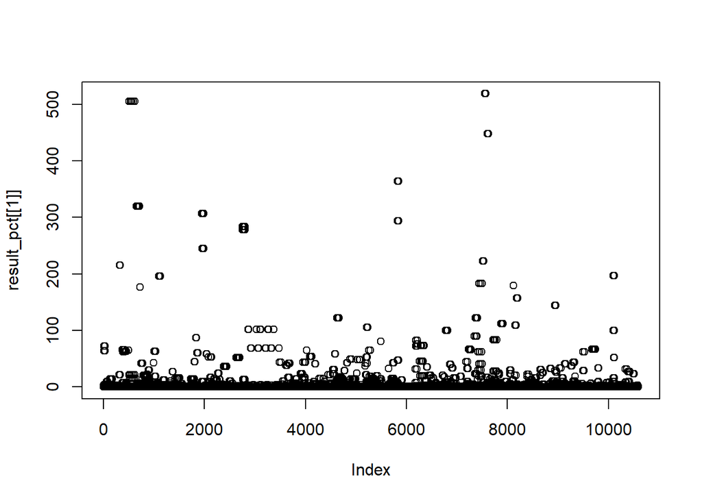

```r
data_sel <- subset(data,
                   select = c(TIEMPO_MUESTRA, PACIENTE_SEXO,
                              PACIENTE_EDAD, RESULTADO, ANALIZADOR,
                              CODIGO_PRUEBA, CTRL))

# Aplicar la transformación wavelet a la variable RESULTADOS para cada grupo de técnica:


# Aplicar la función wavelet_tr al dataframe data_sel
data_wavelet <- wavelet_tr(data_sel)


# Escalograma procalcitonina (CLC00638):
result_pct <- data_sel %>%
  filter(CODIGO_PRUEBA == "CLC00638" &
           ANALIZADOR == "DXI800 num 1") %>%
  select(RESULTADO)

plot(result_pct[[1]])
```

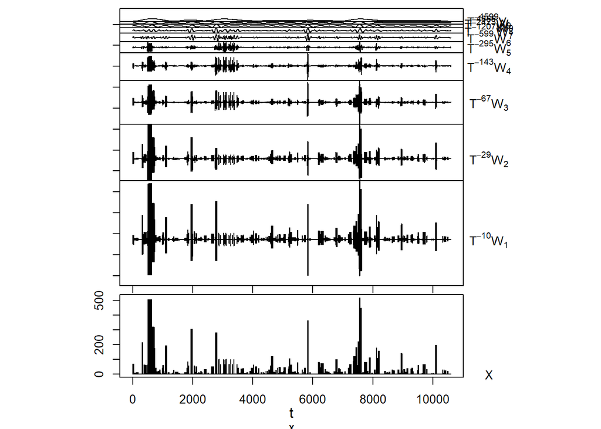

```r
plot.modwt(wt(result_pct, "la20"))
```